# Project: Group Kaggle Notebook

Shawal Fida and Linh Do

## Description of the Data

The dataset for this analysis is a housing price dataset from Kaggle’s House Prices competition. It includes data on various attributes of residential homes in Ames, Iowa, which can help us predict the final sale price of each house. The dataset comprises the following key components:

- **Target Variable**:
  - `SalePrice`: The sale price of each home, which we aim to predict. This continuous variable is the primary target for our model.
- **Predictor Variables**:
  - There are 80 features related to physical characteristics of the properties, including:
    - **Location-based Features**: `Neighborhood`, `LotArea`, and `Street`, which may influence the sale price based on the area and surroundings.
    - **House Size Features**: `GrLivArea` (above-ground living area), `TotalBsmtSF` (basement area), and `1stFlrSF` (1st-floor area).
    - **House Quality Features**: `OverallQual` (overall quality), `YearBuilt`, and `KitchenQual` (kitchen quality), which provide information on the home’s general construction quality and aesthetics.
    - **Garage and Basement Features**: Information about garages (`GarageType`, `GarageCars`, `GarageArea`) and basements (`BsmtQual`, `BsmtCond`, `BsmtExposure`), indicating additional functionality and space.

These variables give a comprehensive view of each home’s characteristics, enabling us to create a predictive model for housing prices.

## Download Data and inspect

```r
test <- read_csv("test.csv")
train <- read_csv("train.csv")
submit_example <- read_csv("sample_submission.csv")
```

```r
# Inspect the first few rows of the training data
head(train)
```

```
## # A tibble: 6 × 81
##      Id MSSubClass MSZoning LotFrontage LotArea Street Alley LotShape
##   <dbl>      <dbl> <chr>          <dbl>   <dbl> <chr>  <chr> <chr>
## 1     1         60 RL                65    8450 Pave   <NA>  Reg
## 2     2         20 RL                80    9600 Pave   <NA>  Reg
## 3     3         60 RL                68   11250 Pave   <NA>  IR1
## 4     4         70 RL                60    9550 Pave   <NA>  IR1
## 5     5         60 RL                84   14260 Pave   <NA>  IR1
## 6     6         50 RL                85   14115 Pave   <NA>  IR1
## # ℹ 73 more variables: LandContour <chr>, Utilities <chr>, LotConfig <chr>,
## #   LandSlope <chr>, Neighborhood <chr>, Condition1 <chr>, Condition2 <chr>,
## #   BldgType <chr>, HouseStyle <chr>, OverallQual <dbl>, OverallCond <dbl>,
## #   YearBuilt <dbl>, YearRemodAdd <dbl>, RoofStyle <chr>, RoofMatl <chr>,
## #   Exterior1st <chr>, Exterior2nd <chr>, MasVnrType <chr>, MasVnrArea <dbl>,
## #   ExterQual <chr>, ExterCond <chr>, Foundation <chr>, BsmtQual <chr>,
## #   BsmtCond <chr>, BsmtExposure <chr>, BsmtFinType1 <chr>, BsmtFinSF1 <dbl>, …
```

```r
# Inspect the first few rows of the test data
head(test)
```

```
## # A tibble: 6 × 80
##      Id MSSubClass MSZoning LotFrontage LotArea Street Alley LotShape
##   <dbl>      <dbl> <chr>          <dbl>   <dbl> <chr>  <chr> <chr>
## 1  1461         20 RH                80   11622 Pave   <NA>  Reg
## 2  1462         20 RL                81   14267 Pave   <NA>  IR1
## 3  1463         60 RL                74   13830 Pave   <NA>  IR1
## 4  1464         60 RL                78    9978 Pave   <NA>  IR1
## 5  1465        120 RL                43    5005 Pave   <NA>  IR1
## 6  1466         60 RL                75   10000 Pave   <NA>  IR1
## # ℹ 72 more variables: LandContour <chr>, Utilities <chr>, LotConfig <chr>,
## #   LandSlope <chr>, Neighborhood <chr>, Condition1 <chr>, Condition2 <chr>,
## #   BldgType <chr>, HouseStyle <chr>, OverallQual <dbl>, OverallCond <dbl>,
## #   YearBuilt <dbl>, YearRemodAdd <dbl>, RoofStyle <chr>, RoofMatl <chr>,
## #   Exterior1st <chr>, Exterior2nd <chr>, MasVnrType <chr>, MasVnrArea <dbl>,
## #   ExterQual <chr>, ExterCond <chr>, Foundation <chr>, BsmtQual <chr>,
## #   BsmtCond <chr>, BsmtExposure <chr>, BsmtFinType1 <chr>, BsmtFinSF1 <dbl>, …
```

```r
# Preview the submission format to see how Kaggle expects predictions to be structured
head(submit_example)
```

```
## # A tibble: 6 × 2
##      Id SalePrice
##   <dbl>     <dbl>
## 1  1461   169277.
## 2  1462   187758.
## 3  1463   183584.
## 4  1464   179317.
## 5  1465   150730.
## 6  1466   177151.
```

## Handling Missing data

In this dataset, there are various predictors with missing values that need to be handled to ensure the model’s accuracy and consistency. Here is an outline of the missing data and the proposed solutions for each:

1. **Categorical Features** (e.g., `Alley`, `PoolQC`, `Fence`, `FireplaceQu`): Missing values in these variables indicate the absence of certain features (e.g., no alley access or no pool). To handle this, I replaced missing values with “None” to capture the absence meaningfully.
2. **Numeric Features** (e.g., `LotFrontage`): Missing values in these fields likely represent missing information rather than an absence of a feature. For such variables, I used the median value to impute missing data, as this is a robust measure that minimizes the impact of outliers.
3. **Garage and Basement Features**: Variables related to garages (`GarageType`, `GarageFinish`, etc.) and basements (`BsmtQual`, `BsmtCond`, etc.) often have missing values when the house lacks a garage or basement. For these, I replaced categorical NAs with “None” and numerical NAs with 0 to indicate non-existence.
4. **Other Variables** (e.g., `Electrical`): For variables like `Electrical` with few missing values, I used the most common category (`"SBrkr"`) to fill in the missing values, assuming that this category is most likely for these cases.

```r
# Function to count missing values in each column
count_missings <- function(x) sum(is.na(x))

# Display the count of missing values in each column
train |>
  summarize_all(count_missings) # Handy summarize_all function
```

```
## # A tibble: 1 × 81
##      Id MSSubClass MSZoning LotFrontage LotArea Street Alley LotShape
##   <int>      <int>    <int>       <int>   <int>  <int> <int>    <int>
## 1     0          0        0         259       0      0  1369        0
## # ℹ 73 more variables: LandContour <int>, Utilities <int>, LotConfig <int>,
## #   LandSlope <int>, Neighborhood <int>, Condition1 <int>, Condition2 <int>,
## #   BldgType <int>, HouseStyle <int>, OverallQual <int>, OverallCond <int>,
## #   YearBuilt <int>, YearRemodAdd <int>, RoofStyle <int>, RoofMatl <int>,
## #   Exterior1st <int>, Exterior2nd <int>, MasVnrType <int>, MasVnrArea <int>,
## #   ExterQual <int>, ExterCond <int>, Foundation <int>, BsmtQual <int>,
## #   BsmtCond <int>, BsmtExposure <int>, BsmtFinType1 <int>, BsmtFinSF1 <int>, …
```

```r
# Load necessary libraries
library(dplyr)
library(tidyr)

# Replace NA in 'Alley' with "None" (indicating no alley access)
train <- train |>
  mutate(Alley = replace_na(Alley, "None"))

# Replace NA in 'LotFrontage' with the median (indicating missing numeric information)
train <- train |>
  mutate(LotFrontage = replace_na(LotFrontage, median(LotFrontage, na.rm = TRUE)))

# Replace NA in 'PoolQC', 'Fence', 'FireplaceQu' with "None" (indicating absence of these features)
train <- train |>
  mutate(PoolQC = replace_na(PoolQC, "None"),
         Fence = replace_na(Fence, "None"),
         FireplaceQu = replace_na(FireplaceQu, "None"))

# Replace NA in Garage-related columns with appropriate values:
# If a house has no garage, 'NA' should be replaced with "None" or 0 as applicable

train <- train |>
  mutate(GarageType = replace_na(GarageType, "None"),
         GarageFinish = replace_na(GarageFinish, "None"),
         GarageQual = replace_na(GarageQual, "None"),
         GarageCond = replace_na(GarageCond, "None"),
         GarageYrBlt = replace_na(GarageYrBlt, 0),
         GarageCars = replace_na(GarageCars, 0),
         GarageArea = replace_na(GarageArea, 0))

# Replace NA in 'MasVnrType' and 'MasVnrArea'
# 'MasVnrType' with "None" for no masonry veneer, and 'MasVnrArea' with 0 for no area
train <- train |>
  mutate(MasVnrType = replace_na(MasVnrType, "None"),
         MasVnrArea = replace_na(MasVnrArea, 0))

# For 'Bsmt' related columns, where NA means no basement
train <- train |>
  mutate(BsmtQual = replace_na(BsmtQual, "None"),
         BsmtCond = replace_na(BsmtCond, "None"),
         BsmtExposure = replace_na(BsmtExposure, "None"),
         BsmtFinType1 = replace_na(BsmtFinType1, "None"),
         BsmtFinType2 = replace_na(BsmtFinType2, "None"),
         BsmtFinSF1 = replace_na(BsmtFinSF1, 0),
         BsmtFinSF2 = replace_na(BsmtFinSF2, 0),
         BsmtUnfSF = replace_na(BsmtUnfSF, 0),
         TotalBsmtSF = replace_na(TotalBsmtSF, 0),
         BsmtFullBath = replace_na(BsmtFullBath, 0),
         BsmtHalfBath = replace_na(BsmtHalfBath, 0))

# Replace NA in 'Electrical' with the most common value
train <- train |>
  mutate(Electrical = replace_na(Electrical, "SBrkr"))

# Verify all missing values have been handled
train |>
  summarize_all(count_missings)
```

```
## # A tibble: 1 × 81
##      Id MSSubClass MSZoning LotFrontage LotArea Street Alley LotShape
##   <int>      <int>    <int>       <int>   <int>  <int> <int>    <int>
## 1     0          0        0           0       0      0     0        0
## # ℹ 73 more variables: LandContour <int>, Utilities <int>, LotConfig <int>,
## #   LandSlope <int>, Neighborhood <int>, Condition1 <int>, Condition2 <int>,
## #   BldgType <int>, HouseStyle <int>, OverallQual <int>, OverallCond <int>,
## #   YearBuilt <int>, YearRemodAdd <int>, RoofStyle <int>, RoofMatl <int>,
## #   Exterior1st <int>, Exterior2nd <int>, MasVnrType <int>, MasVnrArea <int>,
## #   ExterQual <int>, ExterCond <int>, Foundation <int>, BsmtQual <int>,
## #   BsmtCond <int>, BsmtExposure <int>, BsmtFinType1 <int>, BsmtFinSF1 <int>, …
```

## Variable Selection

```r
# Select numeric predictors
numeric_vars <- train |>
  select(where(is.numeric))

# Calculate correlation with SalePrice
correlations <- numeric_vars |>
  cor(use = "complete.obs")

# Extract top correlated variables with SalePrice
top_correlated <- sort(correlations["SalePrice", -1], decreasing = TRUE)
top_correlated
```

```
##     SalePrice   OverallQual     GrLivArea    GarageCars    GarageArea
##    1.00000000    0.79098160    0.70862448    0.64040920    0.62343144
##   TotalBsmtSF      1stFlrSF      FullBath  TotRmsAbvGrd     YearBuilt
##    0.61358055    0.60585218    0.56066376    0.53372316    0.52289733
##  YearRemodAdd    MasVnrArea    Fireplaces    BsmtFinSF1   LotFrontage
##    0.50710097    0.47261450    0.46692884    0.38641981    0.33477085
##    WoodDeckSF      2ndFlrSF   OpenPorchSF      HalfBath       LotArea
##    0.32441344    0.31933380    0.31585623    0.28410768    0.26384335
##   GarageYrBlt  BsmtFullBath     BsmtUnfSF  BedroomAbvGr   ScreenPorch
##    0.26136644    0.22712223    0.21447911    0.16821315    0.11144657
##      PoolArea        MoSold     3SsnPorch    BsmtFinSF2  BsmtHalfBath
##    0.09240355    0.04643225    0.04458367   -0.01137812   -0.01684415
##       MiscVal  LowQualFinSF        YrSold   OverallCond    MSSubClass
##   -0.02118958   -0.02560613   -0.02892259   -0.07785589   -0.08428414
## EnclosedPorch  KitchenAbvGr
##   -0.12857796   -0.13590737
```

```r
# Extract variables with a correlation greater than 0.5
selected_vars <- names(top_correlated[top_correlated > 0.5])

# Include important categorical variables based on domain knowledge
categorical_vars <- c("Neighborhood", "OverallQual", "KitchenQual")

# Final list of selected variables
final_selected_vars <- c(selected_vars, categorical_vars)
final_selected_vars
```

```
##  [1] "SalePrice"    "OverallQual"  "GrLivArea"    "GarageCars"   "GarageArea"
##  [6] "TotalBsmtSF"  "1stFlrSF"     "FullBath"     "TotRmsAbvGrd" "YearBuilt"
## [11] "YearRemodAdd" "Neighborhood" "OverallQual"  "KitchenQual"
```

```r
# Create a reduced dataset with selected variables
model_data <- train |>
  select(all_of(final_selected_vars))

# Preview the reduced dataset
head(model_data)
```

```
## # A tibble: 6 × 13
##   SalePrice OverallQual GrLivArea GarageCars GarageArea TotalBsmtSF `1stFlrSF`
##       <dbl>       <dbl>     <dbl>      <dbl>      <dbl>       <dbl>      <dbl>
## 1    208500           7      1710          2        548         856        856
## 2    181500           6      1262          2        460        1262       1262
## 3    223500           7      1786          2        608         920        920
## 4    140000           7      1717          3        642         756        961
## 5    250000           8      2198          3        836        1145       1145
## 6    143000           5      1362          2        480         796        796
## # ℹ 6 more variables: FullBath <dbl>, TotRmsAbvGrd <dbl>, YearBuilt <dbl>,
## #   YearRemodAdd <dbl>, Neighborhood <chr>, KitchenQual <chr>
```

## Data modeling

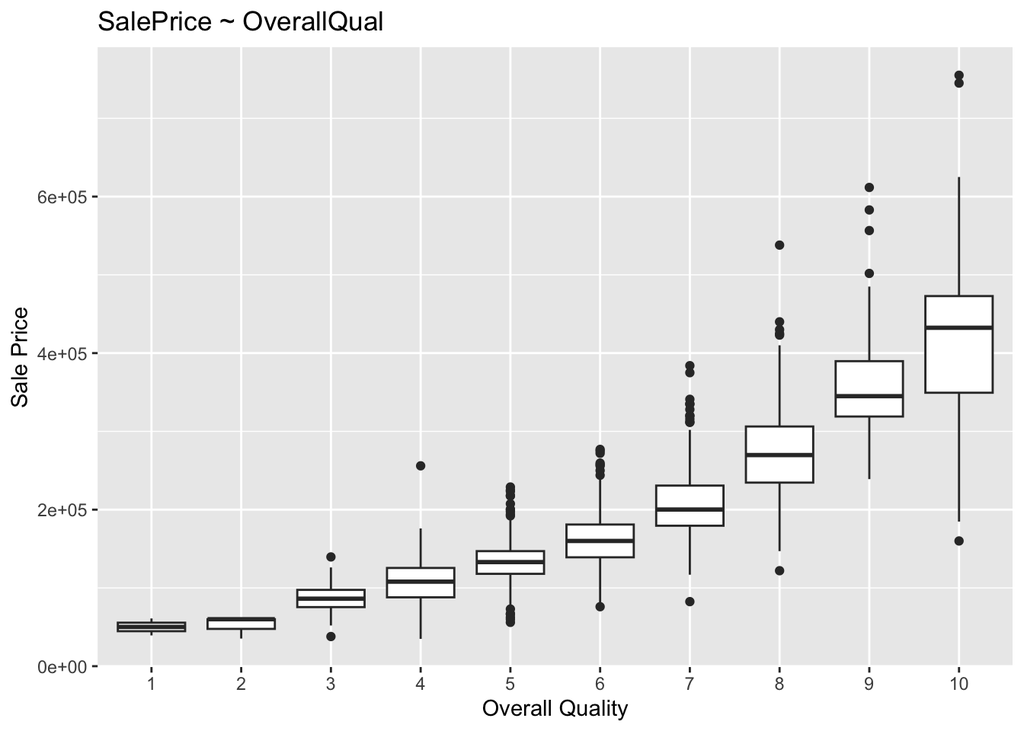

```r
# Load necessary library for visualization
library(ggplot2)

# Box plot to examine the relationship between OverallQual and SalePrice
ggplot(model_data, aes(factor(OverallQual), SalePrice)) +
  geom_boxplot() +
  labs(title = "SalePrice ~ OverallQual",
       x = "Overall Quality",
       y = "Sale Price")
```

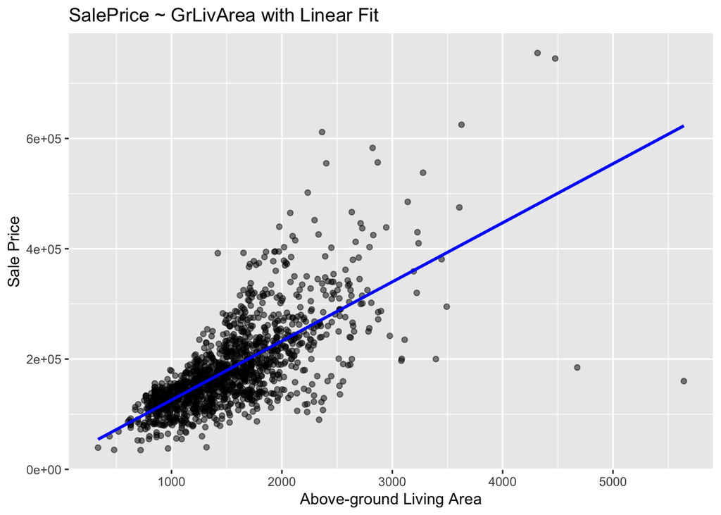

```r
# Scatter plot with linear fit for GrLivArea and SalePrice
ggplot(model_data, aes(GrLivArea, SalePrice)) +
  geom_point(alpha = 0.5) +
  geom_smooth(method = "lm", se = FALSE, col = "blue") +  # Linear fit
  labs(title = "SalePrice ~ GrLivArea with Linear Fit",
       x = "Above-ground Living Area",
       y = "Sale Price")
```

```r
# Fit a simple linear model using OverallQual as numeric
model_numeric <- lm(SalePrice ~ OverallQual, data = model_data)
summary(model_numeric)
```

```
##
## Call:
## lm(formula = SalePrice ~ OverallQual, data = model_data)
##
## Residuals:
##     Min      1Q  Median      3Q     Max
## -198152  -29409   -1845   21463  396848
##
## Coefficients:
##             Estimate Std. Error t value Pr(>|t|)
## (Intercept) -96206.1     5756.4  -16.71   <2e-16 ***
## OverallQual  45435.8      920.4   49.36   <2e-16 ***
## ---
## Signif. codes:  0 '***' 0.001 '**' 0.01 '*' 0.05 '.' 0.1 ' ' 1
##
## Residual standard error: 48620 on 1458 degrees of freedom
## Multiple R-squared:  0.6257, Adjusted R-squared:  0.6254
## F-statistic:  2437 on 1 and 1458 DF,  p-value: < 2.2e-16
```

```r
# Fit a model using OverallQual as a factor
model_factor <- lm(SalePrice ~ factor(OverallQual), data = model_data)
summary(model_factor)
```

```
##
## Call:
## lm(formula = SalePrice ~ factor(OverallQual), data = model_data)
##
## Residuals:
##     Min      1Q  Median      3Q     Max
## -278588  -24023   -2113   19312  316412
##
## Coefficients:
##                       Estimate Std. Error t value Pr(>|t|)
## (Intercept)              50150      31666   1.584 0.113482
## factor(OverallQual)2      1620      40881   0.040 0.968390
## factor(OverallQual)3     37324      33212   1.124 0.261285
## factor(OverallQual)4     58271      31938   1.824 0.068286 .
## factor(OverallQual)5     83373      31746   2.626 0.008724 **
## factor(OverallQual)6    111453      31751   3.510 0.000461 ***
## factor(OverallQual)7    157566      31766   4.960 7.87e-07 ***
## factor(OverallQual)8    224586      31854   7.050 2.75e-12 ***
## factor(OverallQual)9    317363      32395   9.797  < 2e-16 ***
## factor(OverallQual)10   388438      33380  11.637  < 2e-16 ***
## ---
## Signif. codes:  0 '***' 0.001 '**' 0.01 '*' 0.05 '.' 0.1 ' ' 1
##
## Residual standard error: 44780 on 1450 degrees of freedom
## Multiple R-squared:  0.6842, Adjusted R-squared:  0.6822
## F-statistic:   349 on 9 and 1450 DF,  p-value: < 2.2e-16
```

```r
# Compare R-squared values
cat("R-squared for numeric encoding: ", summary(model_numeric)$r.squared, "\n")
```

```
## R-squared for numeric encoding:  0.6256519
```

```r
cat("R-squared for factor encoding: ", summary(model_factor)$r.squared, "\n")
```

```
## R-squared for factor encoding:  0.6841813
```

```r
# Update dataset to treat OverallQual as a factor for further modeling
model_data <- model_data |> mutate(OverallQual = factor(OverallQual))
```

## Cross validation

1. Split the Data (70/30 Split)

```r
set.seed(123)  # Set seed for reproducibility

# Create training and validation splits
train_index <- sample(1:nrow(model_data), size = 0.7 * nrow(model_data), replace = FALSE)
train_fold <- model_data[train_index, ]
validation_fold <- model_data[-train_index, ]
```

2. Fit a Linear Model on the Training Data

```r
# Fit the linear regression model
model <- lm(SalePrice ~ ., data = train_fold)

# View the model summary for insights
summary(model)
```

```
##
## Call:
## lm(formula = SalePrice ~ ., data = train_fold)
##
## Residuals:
##     Min      1Q  Median      3Q     Max
## -383806  -13381      44   12619  244272
##
## Coefficients:
##                       Estimate Std. Error t value Pr(>|t|)
## (Intercept)         -6.429e+05  2.160e+05  -2.976 0.002991 **
## OverallQual2        -5.986e+03  4.211e+04  -0.142 0.886972
## OverallQual3        -8.953e+03  2.712e+04  -0.330 0.741364
## OverallQual4         7.497e+03  2.570e+04   0.292 0.770594
## OverallQual5         9.643e+03  2.574e+04   0.375 0.707968
## OverallQual6         1.744e+04  2.584e+04   0.675 0.499845
## OverallQual7         2.709e+04  2.609e+04   1.038 0.299404
## OverallQual8         5.657e+04  2.643e+04   2.140 0.032579 *
## OverallQual9         1.055e+05  2.756e+04   3.827 0.000138 ***
## OverallQual10        1.212e+05  2.898e+04   4.180 3.18e-05 ***
## GrLivArea            3.901e+01  5.075e+00   7.686 3.69e-14 ***
## GarageCars           9.904e+03  3.474e+03   2.851 0.004455 **
## GarageArea           3.772e+00  1.154e+01   0.327 0.743947
## TotalBsmtSF          1.493e+01  4.920e+00   3.035 0.002470 **
## `1stFlrSF`           1.351e+00  6.049e+00   0.223 0.823289
## FullBath             5.925e+02  3.115e+03   0.190 0.849175
## TotRmsAbvGrd         1.127e+03  1.290e+03   0.873 0.382859
## YearBuilt            1.012e+02  9.107e+01   1.111 0.266904
## YearRemodAdd         2.582e+02  7.804e+01   3.308 0.000974 ***
## NeighborhoodBlueste -1.674e+04  3.584e+04  -0.467 0.640592
## NeighborhoodBrDale  -2.429e+04  1.510e+04  -1.609 0.108017
## NeighborhoodBrkSide  2.598e+03  1.282e+04   0.203 0.839420
## NeighborhoodClearCr  2.543e+04  1.270e+04   2.003 0.045505 *
## NeighborhoodCollgCr  9.225e+03  1.006e+04   0.917 0.359341
## NeighborhoodCrawfor  3.425e+04  1.221e+04   2.805 0.005134 **
## NeighborhoodEdwards -1.353e+04  1.136e+04  -1.191 0.233938
## NeighborhoodGilbert  7.956e+03  1.064e+04   0.748 0.454771
## NeighborhoodIDOTRR  -1.247e+04  1.363e+04  -0.915 0.360498
## NeighborhoodMeadowV -1.394e+04  1.515e+04  -0.920 0.357574
## NeighborhoodMitchel  2.629e+03  1.135e+04   0.232 0.816795
## NeighborhoodNAmes    5.057e+03  1.073e+04   0.471 0.637706
## NeighborhoodNoRidge  6.164e+04  1.188e+04   5.186 2.61e-07 ***
## NeighborhoodNPkVill -4.518e+03  1.655e+04  -0.273 0.784954
## NeighborhoodNridgHt  3.748e+04  1.075e+04   3.486 0.000511 ***
## NeighborhoodNWAmes   5.159e+03  1.100e+04   0.469 0.639016
## NeighborhoodOldTown -1.705e+04  1.222e+04  -1.395 0.163381
## NeighborhoodSawyer   2.191e+03  1.114e+04   0.197 0.844204
## NeighborhoodSawyerW  7.923e+03  1.086e+04   0.730 0.465835
## NeighborhoodSomerst  1.296e+04  1.047e+04   1.238 0.216167
## NeighborhoodStoneBr  5.773e+04  1.271e+04   4.541 6.28e-06 ***
## NeighborhoodSWISU   -8.323e+03  1.448e+04  -0.575 0.565446
## NeighborhoodTimber   2.087e+04  1.145e+04   1.823 0.068585 .
## NeighborhoodVeenker  3.516e+04  1.497e+04   2.348 0.019066 *
## KitchenQualFa       -3.434e+04  9.926e+03  -3.459 0.000565 ***
## KitchenQualGd       -2.376e+04  5.544e+03  -4.285 2.01e-05 ***
## KitchenQualTA       -3.015e+04  6.122e+03  -4.925 9.93e-07 ***
## ---
## Signif. codes:  0 '***' 0.001 '**' 0.01 '*' 0.05 '.' 0.1 ' ' 1
##
## Residual standard error: 34190 on 975 degrees of freedom
## Multiple R-squared:  0.8235, Adjusted R-squared:  0.8153
## F-statistic: 101.1 on 45 and 975 DF,  p-value: < 2.2e-16
```

3. Evaluate the Model on the Validation Set

```r
# Generate predictions for the validation set
predictions <- predict(model, newdata = validation_fold)

# Define RMSE function
rmse <- function(observed, predicted) {
    sqrt(mean((observed - predicted)^2))
}

# Define R-squared function
R2 <- function(observed, predicted) {
    1 - (sum((observed - predicted)^2) / sum((observed - mean(observed))^2))
}

# Calculate RMSE and R-squared for validation set
rmse_val <- rmse(validation_fold$SalePrice, predictions)
r2_val <- R2(validation_fold$SalePrice, predictions)

# Display results
cat("RMSE on Validation Set:", rmse_val, "\n")
```

```
## RMSE on Validation Set: 28229.5
```

```r
cat("R-squared on Validation Set:", r2_val, "\n")
```

```
## R-squared on Validation Set: 0.872829
```

Since our model already exceeds the desired benchmark R-squared of 0.85, achieving an R-squared of 0.872 on the validation set, we find that the current set of predictors is sufficient for explaining the variance in SalePrice. Therefore, experimenting with alternative predictors to further improve the model’s performance is not necessary in this case. We can proceed to finalize the model and make predictions on the test set.

## Final Submission Steps

1. Fit the Final Model Using the Entire Training Set:

```r
# Fit the linear regression model to the entire training set
final_model <- lm(SalePrice ~ ., data = model_data)

# View the model summary for insights
summary(final_model)
```

```
##
## Call:
## lm(formula = SalePrice ~ ., data = model_data)
##
## Residuals:
##     Min      1Q  Median      3Q     Max
## -420410  -13272     681   12223  221471
##
## Coefficients:
##                       Estimate Std. Error t value Pr(>|t|)
## (Intercept)         -7.853e+05  1.658e+05  -4.736 2.40e-06 ***
## OverallQual2        -4.889e+03  2.974e+04  -0.164 0.869427
## OverallQual3        -6.203e+03  2.457e+04  -0.252 0.800737
## OverallQual4         6.030e+03  2.370e+04   0.254 0.799222
## OverallQual5         9.839e+03  2.371e+04   0.415 0.678249
## OverallQual6         1.644e+04  2.376e+04   0.692 0.489074
## OverallQual7         2.851e+04  2.394e+04   1.191 0.233931
## OverallQual8         5.296e+04  2.419e+04   2.190 0.028711 *
## OverallQual9         1.097e+05  2.498e+04   4.390 1.22e-05 ***
## OverallQual10        1.339e+05  2.594e+04   5.161 2.80e-07 ***
## GrLivArea            4.253e+01  3.962e+00  10.734  < 2e-16 ***
## GarageCars           9.632e+03  2.739e+03   3.516 0.000452 ***
## GarageArea           6.389e+00  9.302e+00   0.687 0.492292
## TotalBsmtSF          1.473e+01  3.723e+00   3.957 7.97e-05 ***
## `1stFlrSF`           3.137e+00  4.496e+00   0.698 0.485476
## FullBath             2.517e+01  2.438e+03   0.010 0.991766
## TotRmsAbvGrd         3.415e+02  1.002e+03   0.341 0.733344
## YearBuilt            1.686e+02  6.728e+01   2.505 0.012343 *
## YearRemodAdd         2.586e+02  6.089e+01   4.247 2.31e-05 ***
## NeighborhoodBlueste -5.035e+03  2.446e+04  -0.206 0.836924
## NeighborhoodBrDale  -1.220e+04  1.195e+04  -1.021 0.307572
## NeighborhoodBrkSide  1.253e+04  1.020e+04   1.228 0.219559
## NeighborhoodClearCr  3.980e+04  1.046e+04   3.806 0.000147 ***
## NeighborhoodCollgCr  1.597e+04  8.471e+03   1.885 0.059668 .
## NeighborhoodCrawfor  4.352e+04  9.978e+03   4.362 1.38e-05 ***
## NeighborhoodEdwards -2.941e+03  9.322e+03  -0.315 0.752432
## NeighborhoodGilbert  1.423e+04  8.931e+03   1.593 0.111320
## NeighborhoodIDOTRR  -3.590e+03  1.088e+04  -0.330 0.741549
## NeighborhoodMeadowV -9.491e+03  1.189e+04  -0.798 0.424957
## NeighborhoodMitchel  9.653e+03  9.519e+03   1.014 0.310691
## NeighborhoodNAmes    1.157e+04  8.924e+03   1.296 0.195166
## NeighborhoodNoRidge  6.811e+04  9.883e+03   6.892 8.28e-12 ***
## NeighborhoodNPkVill  1.772e+03  1.380e+04   0.128 0.897871
## NeighborhoodNridgHt  4.023e+04  9.130e+03   4.406 1.13e-05 ***
## NeighborhoodNWAmes   1.396e+04  9.133e+03   1.528 0.126664
## NeighborhoodOldTown -6.684e+03  9.932e+03  -0.673 0.501050
## NeighborhoodSawyer   9.378e+03  9.406e+03   0.997 0.318930
## NeighborhoodSawyerW  1.388e+04  9.155e+03   1.516 0.129695
## NeighborhoodSomerst  1.876e+04  8.831e+03   2.124 0.033823 *
## NeighborhoodStoneBr  5.577e+04  1.052e+04   5.304 1.32e-07 ***
## NeighborhoodSWISU    2.340e+03  1.155e+04   0.203 0.839514
## NeighborhoodTimber   2.903e+04  9.636e+03   3.012 0.002638 **
## NeighborhoodVeenker  4.681e+04  1.275e+04   3.670 0.000252 ***
## KitchenQualFa       -3.385e+04  7.643e+03  -4.428 1.02e-05 ***
## KitchenQualGd       -2.345e+04  4.568e+03  -5.134 3.24e-07 ***
## KitchenQualTA       -2.901e+04  5.049e+03  -5.747 1.11e-08 ***
## ---
## Signif. codes:  0 '***' 0.001 '**' 0.01 '*' 0.05 '.' 0.1 ' ' 1
##
## Residual standard error: 32230 on 1414 degrees of freedom
## Multiple R-squared:  0.8405, Adjusted R-squared:  0.8354
## F-statistic: 165.6 on 45 and 1414 DF,  p-value: < 2.2e-16
```

2. Prepare the Test Set

```r
# Prepare the test set with the same transformations as the training set
test <- test |>
  mutate(
    OverallQual = factor(OverallQual),
    GrLivArea = replace_na(GrLivArea, median(model_data$GrLivArea, na.rm = TRUE)),
    TotalBsmtSF = replace_na(TotalBsmtSF, median(model_data$TotalBsmtSF, na.rm = TRUE)),
    GarageCars = replace_na(GarageCars, median(model_data$GarageCars, na.rm = TRUE)),
    YearBuilt = replace_na(YearBuilt, median(model_data$YearBuilt, na.rm = TRUE))
  )

# Verify there are no missing values in the test set
test |> summarize_all(~ sum(is.na(.)))
```

```
## # A tibble: 1 × 80
##      Id MSSubClass MSZoning LotFrontage LotArea Street Alley LotShape
##   <int>      <int>    <int>       <int>   <int>  <int> <int>    <int>
## 1     0          0        4         227       0      0  1352        0
## # ℹ 72 more variables: LandContour <int>, Utilities <int>, LotConfig <int>,
## #   LandSlope <int>, Neighborhood <int>, Condition1 <int>, Condition2 <int>,
## #   BldgType <int>, HouseStyle <int>, OverallQual <int>, OverallCond <int>,
## #   YearBuilt <int>, YearRemodAdd <int>, RoofStyle <int>, RoofMatl <int>,
## #   Exterior1st <int>, Exterior2nd <int>, MasVnrType <int>, MasVnrArea <int>,
## #   ExterQual <int>, ExterCond <int>, Foundation <int>, BsmtQual <int>,
## #   BsmtCond <int>, BsmtExposure <int>, BsmtFinType1 <int>, BsmtFinSF1 <int>, …
```

3. Make Predictions for the Test Set:

```r
# Generate predictions for the test set
submission_predictions <- predict(final_model, newdata = test)

# Format the submission file to match Kaggle requirements
submission <- test |>
  select(Id) |>
  mutate(SalePrice = submission_predictions)

# Preview the submission file
head(submission)
```

```
## # A tibble: 6 × 2
##      Id SalePrice
##   <dbl>     <dbl>
## 1  1461   114591.
## 2  1462   149501.
## 3  1463   173253.
## 4  1464   184752.
## 5  1465   252343.
## 6  1466   176379.
```

4. Save the submission file.

```r
# Save your predictions to a CSV file
write.csv(submission, "~/Downloads/kaggle_group_submission.csv", row.names = FALSE)
```

## Group Members and their contribution

- **Linh Do**
- Handled the data preprocessing phase, including missing value imputation and encoding of categorical variables. Analyzed model performance metrics and created visualizations.
- **Shawal Fida**
- Conducted exploratory data analysis (EDA) to identify patterns and relationships within the dataset. Implemented regression models and conducted cross-validation for model evaluation.